# Laboratorio 3.2: Clustering

**Autores:** Felipe Bravo-Marquez, Hernán Sarmiento, Gabriel Iturra-Bocaz, María José Zambrano

**Fecha:** Mayo 2023

## ============= Declaración de compromiso ético =============

Nosotros Javier Kauer y Diego Faúndez, de la sección 2, declaramos que realizamos de manera grupal los pasos de la presente actividad. También declaramos no incurrir en copia, ni compartir nuestras respuestas con otras personas ni con otros grupos. Por lo que, ratificamos que las respuestas son de nuestra propia confección y reflejan nuestro propio conocimiento.

# Instrucciones

1. Trabajen en equipos de dos personas. Salvo excepciones, no se corregirá entregas con menos de dos integrantes.
2. Modifiquen este archivo `.ipynb` agregando sus respuestas donde corresponda.
3. Cuando finalicen el laboratorio, **generen un archivo HTML** usando jupyter (ver tutorial 3) y súbanlo a U-Cursos. El laboratorio debe ser entregado sólo por 1 integrante. Si se entrega por más de un integrante, se revisará cualquiera de éstos.

# Estructura del laboratorio

Este laboratorio consiste en 2 partes. La primera son preguntas teóricas en las que no necesita escribir código y corresponden a materia vista en clases. La segunda es una sección para evaluar los métodos de clustering.

# Parte 1: Teoría

**1.** De acuerdo a lo visto en clases, explique cómo bisecting k-mean soluciona el problema de la inicialización de centroides de k-means.

Como se realizan varios intentos de bisección y se termina quedando la de menor SSE, al finalizar quedan los clusters solicitados definidos de manera más precisa.

**2.** Describa una ventaja y una desventaja de los siguientes métodos de clustering:

- K-Means

Ventaja:Método sencillo y rápido.

Desventaja: No es robusto a Outliers.

- Clustering Jerarquico Aglomerativo

Ventaja: No necesita indicarse un número previo de clusters. Se puede obtener un número deseado al realizar un "corte" en el dendograma.

Desventaja: La union de clusters es irreversible, por lo que uniones hechas previamente en el algoritmo influirán fuertemente en el modelo final.

**3.** Evaluar clusters no es una tarea fácil. ¿Qué formas de evaluar clusters conoce? Nombre 3 formas de validación y describa cómo podría determinar si los clusters son buenos o malos usando cada una de las formas nombradas.

La primera forma para evaluar clusters corresponde al método validación de un experto, en donde los clusters se ven validados con respecto a un experto que conozca del tema, y sepa concluir que tan correcto es el cluster obtenido. El segundo método corresponde a el método de medidas internas (Internal Index), ocupando el concepto de cohesion del cluster, y separación con otros clusters, en donde se analiza que tan similares es un cluster consigo mismo, y que tan distintos es con otros clusters, de esta forma si un cluster está muy cohesionado y separado con otros clusters es bueno, y malo en el caso contrario. El último método es el coeficiente de silhouette, el cual corresponde a una expansión del método anterior, en donde se hace un cálculo de distancia de un punto de un cluster, con todos los otros puntos del dataset, de esta forma se obtiene un coeficiente que mientras más cercano a 1, mejor, y más cercano a -1, peor.

**4.** Según lo visto en clases, explique el enfoque visual para comparar clusters mediante matrices de proximidad. ¿Qué características debe tener la matriz para determinar que una clusterización es buena? ¿En qué casos la matriz de proximidad no es útil para evaluar clustering?

Las características para determinar que una clusterización es buena corresponde a encontrar bloques, o patrones dentro de la matriz, de tal forma que se pueda identificar correctamente clusters de forma individual, y no un patrón que se encuentra a lo largo de toda la matriz. Los casos en donde no es útil ocupar la matriz de proximidad para evaluar un clustering corresponde cuando existe una alta dimensionalidad de la matriz, causando que sea dificil evaluar correctamente los valores entre todas las dimensiones.

# Parte 2: Clustering

Para esta parte del Laboratorio vamos a evaluar dos métodos de clustering: `k-means` y `dbscan`. Ejecute las siguientes líneas para descargar y seleccionar los datos.

```python
from sklearn.cluster import DBSCAN
import pandas as pd

dataframe = pd.read_csv("https://raw.githubusercontent.com/giturra/Lab3.2/main/D31.txt", sep="\t")
X = pd.DataFrame(dataframe).to_numpy()[:, 0:2]
X
```

```
array([[26.6614,  7.3414],
       [25.2653,  6.2466],
       [25.2285,  4.7447],
       ...,
       [ 5.276 , 17.2475],
       [ 6.4444, 16.2033],
       [ 7.162 , 18.1836]])
```

## K-Means

**1.** Cuando usamos K-Means debemos definir previamente el número de clusters que queremos generar. Teniendo en cuenta estos datos, implemente el método del codo.

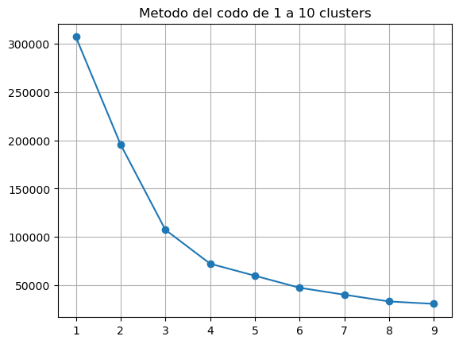

```python
# Respuesta
import matplotlib.pyplot as plt
from sklearn.cluster import KMeans

sse = []

clusters = list(range(1, 10))
for k in clusters:
    kmeans = KMeans(n_clusters=k,n_init='auto').fit(X)
    sse.append(kmeans.inertia_)

plt.plot(clusters, sse, marker="o")
plt.title("Metodo del codo de 1 a 10 clusters")
plt.grid(True)
plt.show()
```

**2.** ¿Cuántos clusters propone usar para este dataset? Escoja dos opciones y justifique su elección.

Se propone usar entre 4 y 5 clusters para el dataset, ya que es en estos puntos donde la pendiente entre puntos comienza a ser menos pronunciada, por lo que ahí debería estar el punto de diminishing returns.

**3.** Genere un gráfico para cada uno de los dos `k` elegidos para tener una representación visual de los clusters.

[figure not shown]

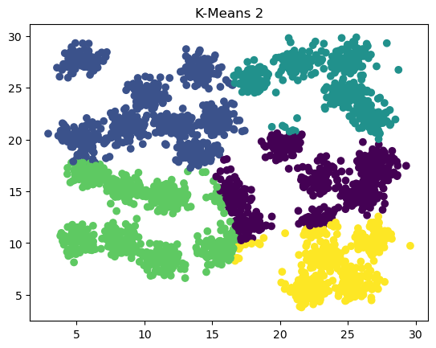

```python
# Respuesta
kmeans1 = KMeans(n_clusters=4, random_state=20,n_init='auto').fit(X)
kmeans2 = KMeans(n_clusters=5, random_state=20,n_init='auto').fit(X)

plt.scatter(X[:, 0], X[:, 1], c=kmeans.labels_)
plt.title("K-Means 1")
plt.show()

plt.scatter(X[:, 0], X[:, 1], c=kmeans2.labels_)
plt.title("K-Means 2")
plt.show()
```

## DBSCAN

**1.** Usando los datos anteriores, ejecute DBSCAN y genere un gráfico con los clusters obtenidos. Use los parámetros `eps=0.9`y `min_samples=5`.

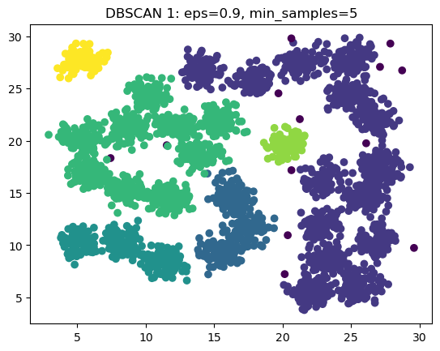

```python
# Respuesta
from  sklearn.cluster import DBSCAN

eps = 0.9
min_samples = 5

dbscan1 = DBSCAN(eps=eps, min_samples=min_samples).fit(X)
plt.scatter(X[:,0], X[:,1], c=dbscan1.labels_)
plt.title(f"DBSCAN 1: eps={eps}, min_samples={min_samples}")
plt.show()
```

**2.** Estime el valor `eps` usando el método de la rodilla (basado en KNN). La idea de este procedimiento es calcular la distancia promedio de cada punto a sus `k` vecinos más cercanos los cuales son graficados en orden ascendente. El objetivo es determinar la *rodilla*, que corresponde al valor óptimo de `eps`. Pruebe varios valores de `y` utilizando el siguiente código y adjunte el gráfico para el mejor `y` que usted considere. Explique porque escogio el valor `y` como mejor opción.

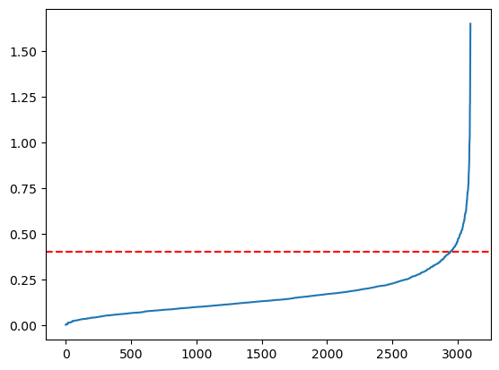

```python
#Respuesta

from sklearn.neighbors import NearestNeighbors
import numpy as np

nbrs = NearestNeighbors(n_neighbors=3).fit(X)
distances, indices = nbrs.kneighbors(X)

distances = np.sort(distances, axis=0)
distances = distances[:,1]
plt.axhline(y=0.4, color='r', linestyle='--')
plt.plot(distances)
```

**Explicacion:** Se eligió el 0.4 ya que este es el punto de inflexión de la curva, por lo que desde este punto, el añadir más vecinos no aporta al modelo.

**3.** Ejecute y grafique los clusters usando el método DBSCAN haciendo uso de parámetro `eps` (`y`) encontrado previamente.

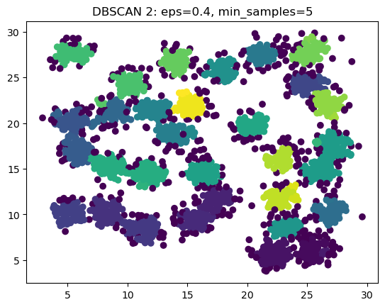

```python
# Respuesta

from  sklearn.cluster import DBSCAN

eps = 0.4
min_samples = 5

dbscan2 = DBSCAN(eps=eps, min_samples=min_samples).fit(X)
plt.scatter(X[:,0], X[:,1], c=dbscan2.labels_)
plt.title(f"DBSCAN 2: eps={eps}, min_samples={min_samples}")
plt.show()
```

## Evaluación

**1.** Para evaluar clusters existen una serie de métodos y métricas. Para este laboratorio usaremos el coeficiente de Silhouette. Para cada uno de los experimentos (los dos de la parte de `kmeans` en la pregunta **3** y los dos de la parte de `dbscan` en la pregunta **1** y **3**), adjunte el código que permita obtener el Silhouette score de los modelos.

```python
# Respuesta
from sklearn.metrics import silhouette_score
print("KMeans 1", silhouette_score(X, kmeans1.labels_))
print("KMeans 2", silhouette_score(X, kmeans2.labels_))
# Filtrando el ruido en DBScan
_filter_label1 = dbscan1.labels_ >= 0
print("DBScan 1", silhouette_score(X[_filter_label1], dbscan1.labels_[_filter_label1]))
_filter_label2 = dbscan2.labels_ >= 0
print("DBScan 2", silhouette_score(X[_filter_label2], dbscan2.labels_[_filter_label2]))
```

```
KMeans 1 0.4275146223314558
KMeans 2 0.4118344321035776
DBScan 1 0.08293147312207123
DBScan 2 0.4488898192986067
```

**2.** En base a los valores del coeficiente de Silhouette obtenidos para cada método y configuración. ¿Cuál cree que es el que tiene mejor resultado? Comente al respecto basándose principalmente en los resultados.

> Respuesta

En base a los valores obtenidos para cada método, el que tiene el mejor resultador corresponde al clustering que se hizo en la pregunta 3, el que ocupa DBScan con un eps estimado con el método de la rodilla. Esto se debe porque el coeficiente obtenido es el más cercano a 1, por lo tanto se puede que el DBScan con eps estimado es el mejor.